# IMDB Scoring

Peters

8/31/2020

https://github.com/Jonpeters3/IMDB

This analysis was done as a class for my “Experimental Learning through Kaggle” class at BYU. As I will explain later on, not all of this code is my own. Much of the data cleaning was completed by others in my class. We stared this analysis working together as a class, but once it came fitting a model, we had a competition to see whose model would be the best. I am pleased to say that I finished in second place!

Data for this model was part of an InClass competition hosted through Kaggle and id available through my github.

```r
test <- read.csv("imdb495/imdbTest.csv")
train <- read.csv("imdb495/imdbTrain.csv")
```

Because of all of the cleaning and imputations we will perform, we are going to combine our data sets so that we can have nice, clean, consistent data.

```r
names(test)[names(test) == "Id"] <- "movie_title"
train <- bind_rows(train = train, test = test, .id="Set")
str(train)
```

```
## 'data.frame':    3426 obs. of  29 variables:
##  $ Set                      : chr  "train" "train" "train" "train" ...
##  $ color                    : chr  "Color" "Color" "Color" "Color" ...
##  $ director_name            : chr  "James Cameron" "Gore Verbinski" "Christopher Nolan" "Sam Raimi" ...
##  $ num_critic_for_reviews   : int  723 302 813 392 324 673 434 313 450 733 ...
##  $ duration                 : int  178 169 164 156 100 183 169 151 150 143 ...
##  $ director_facebook_likes  : int  0 563 22000 0 15 0 0 563 563 0 ...
##  $ actor_3_facebook_likes   : int  855 1000 23000 4000 284 2000 903 1000 1000 748 ...
##  $ actor_2_name             : chr  "Joel David Moore" "Orlando Bloom" "Christian Bale" "James Franco" ...
##  $ actor_1_facebook_likes   : int  1000 40000 27000 24000 799 15000 18000 40000 40000 15000 ...
##  $ gross                    : int  760505847 309404152 448130642 336530303 200807262 330249062 200069408 423032628 89289910 291021565 ...
##  $ genres                   : chr  "Action|Adventure|Fantasy|Sci-Fi" "Action|Adventure|Fantasy" "Action|Thriller" "Action|Adventure|Romance" ...
##  $ actor_1_name             : chr  "CCH Pounder" "Johnny Depp" "Tom Hardy" "J.K. Simmons" ...
##  $ movie_title              : chr  "AvatarÂ " "Pirates of the Caribbean: At World's EndÂ " "The Dark Knight RisesÂ " "Spider-Man 3Â " ...
##  $ num_voted_users          : int  886204 471220 1144337 383056 294810 371639 240396 522040 181792 548573 ...
##  $ cast_total_facebook_likes: int  4834 48350 106759 46055 2036 24450 29991 48486 45757 20495 ...
##  $ actor_3_name             : chr  "Wes Studi" "Jack Davenport" "Joseph Gordon-Levitt" "Kirsten Dunst" ...
##  $ facenumber_in_poster     : int  0 0 0 0 1 0 0 2 1 0 ...
##  $ plot_keywords            : chr  "avatar|future|marine|native|paraplegic" "goddess|marriage ceremony|marriage proposal|pirate|singapore" "deception|imprisonment|lawlessness|police officer|terrorist plot" "sandman|spider man|symbiote|venom|villain" ...
##  $ movie_imdb_link          : chr  "http://www.imdb.com/title/tt0499549/?ref_=fn_tt_tt_1" "http://www.imdb.com/title/tt0449088/?ref_=fn_tt_tt_1" "http://www.imdb.com/title/tt1345836/?ref_=fn_tt_tt_1" "http://www.imdb.com/title/tt0413300/?ref_=fn_tt_tt_1" ...
##  $ num_user_for_reviews     : int  3054 1238 2701 1902 387 3018 2367 1832 711 2536 ...
##  $ language                 : chr  "English" "English" "English" "English" ...
##  $ country                  : chr  "USA" "USA" "USA" "USA" ...
##  $ content_rating           : chr  "PG-13" "PG-13" "PG-13" "PG-13" ...
##  $ budget                   : int  237000000 300000000 250000000 258000000 260000000 250000000 209000000 225000000 215000000 225000000 ...
##  $ title_year               : int  2009 2007 2012 2007 2010 2016 2006 2006 2013 2013 ...
##  $ actor_2_facebook_likes   : int  936 5000 23000 11000 553 4000 10000 5000 2000 3000 ...
##  $ imdb_score               : num  7.9 7.1 8.5 6.2 7.8 6.9 6.1 7.3 6.5 7.2 ...
##  $ aspect_ratio             : num  1.78 2.35 2.35 2.35 1.85 2.35 2.35 2.35 2.35 2.35 ...
##  $ movie_facebook_likes     : int  33000 0 164000 0 29000 197000 0 5000 48000 118000 ...
```

### **Data summary**

In this portion of our analysis, we wanted to get a feel for our data and be able to visualize some of the relationships we have between our variables.

```r
summary(train)
```

```
##      Set               color           director_name
##  Length:3426        Length:3426        Length:3426
##  Class :character   Class :character   Class :character
##  Mode  :character   Mode  :character   Mode  :character
##
##
##
##
##  num_critic_for_reviews    duration     director_facebook_likes
##  Min.   :  1.0          Min.   :  7.0   Min.   :    0.0
##  1st Qu.: 62.0          1st Qu.: 94.0   1st Qu.:   10.0
##  Median :121.0          Median :104.0   Median :   56.0
##  Mean   :150.6          Mean   :108.4   Mean   :  872.2
##  3rd Qu.:205.0          3rd Qu.:118.0   3rd Qu.:  218.0
##  Max.   :813.0          Max.   :330.0   Max.   :23000.0
##  NA's   :11             NA's   :1
##  actor_3_facebook_likes actor_2_name       actor_1_facebook_likes
##  Min.   :    0.0        Length:3426        Min.   :     0
##  1st Qu.:  204.0        Class :character   1st Qu.:   743
##  Median :  442.0        Mode  :character   Median :  1000
##  Mean   :  751.4                           Mean   :  7510
##  3rd Qu.:  691.0                           3rd Qu.: 12000
##  Max.   :23000.0                           Max.   :640000
##  NA's   :9                                 NA's   :3
##      gross              genres          actor_1_name       movie_title
##  Min.   :      703   Length:3426        Length:3426        Length:3426
##  1st Qu.: 10559292   Class :character   Class :character   Class :character
##  Median : 32853640   Mode  :character   Mode  :character   Mode  :character
##  Mean   : 55788260
##  3rd Qu.: 73012108
##  Max.   :760505847
##  NA's   :347
##  num_voted_users   cast_total_facebook_likes actor_3_name
##  Min.   :      5   Min.   :     0            Length:3426
##  1st Qu.:  13469   1st Qu.:  1936            Class :character
##  Median :  44480   Median :  3915            Mode  :character
##  Mean   :  97053   Mean   : 11201
##  3rd Qu.: 113475   3rd Qu.: 15570
##  Max.   :1689764   Max.   :656730
##
```

[output cut: 17 more lines]

```
##  Min.   :      218   Min.   :1916   Min.   :     0         Min.   :1.900
##  1st Qu.:  8000000   1st Qu.:1998   1st Qu.:   394         1st Qu.:5.700
##  Median : 22000000   Median :2004   Median :   685         Median :6.500
##  Mean   : 36839347   Mean   :2002   Mean   :  1945         Mean   :6.367
##  3rd Qu.: 50000000   3rd Qu.:2010   3rd Qu.:   970         3rd Qu.:7.100
##  Max.   :300000000   Max.   :2016   Max.   :137000         Max.   :9.300
##  NA's   :181                        NA's   :5              NA's   :340
##   aspect_ratio    movie_facebook_likes
##  Min.   : 1.180   Min.   :     0.0
##  1st Qu.: 1.850   1st Qu.:     0.0
##  Median : 1.850   Median :   216.5
##  Mean   : 2.109   Mean   :  8309.3
##  3rd Qu.: 2.350   3rd Qu.:  7000.0
##  Max.   :16.000   Max.   :349000.0
##
```

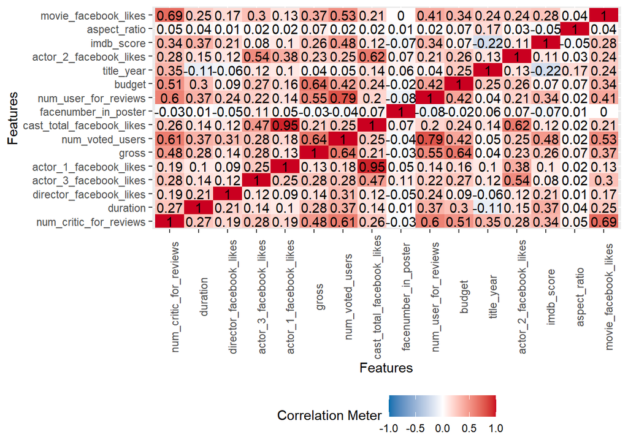

```r
plot_correlation(train, type="continuous",
                 cor_args=list(use="pairwise.complete.obs"))
```

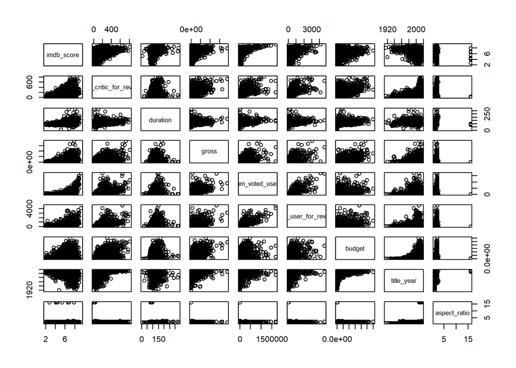

```r
pairs(~imdb_score+num_critic_for_reviews+duration+gross+num_voted_users+num_user_for_reviews+budget+title_year+aspect_ratio, data = train)
```

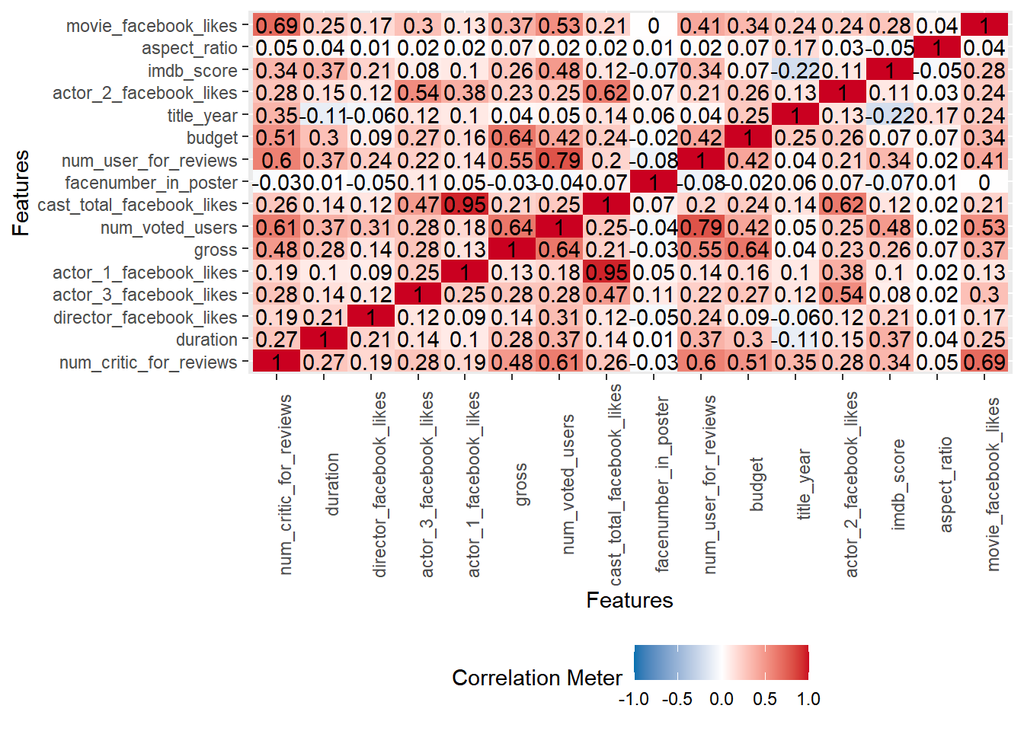

```r
plot_correlation(train, type="continuous",
                 cor_args=list(use="pairwise.complete.obs"))
```

So there does seem to still be some normality issues in parts of our data, so we will see how this affects our model later one.

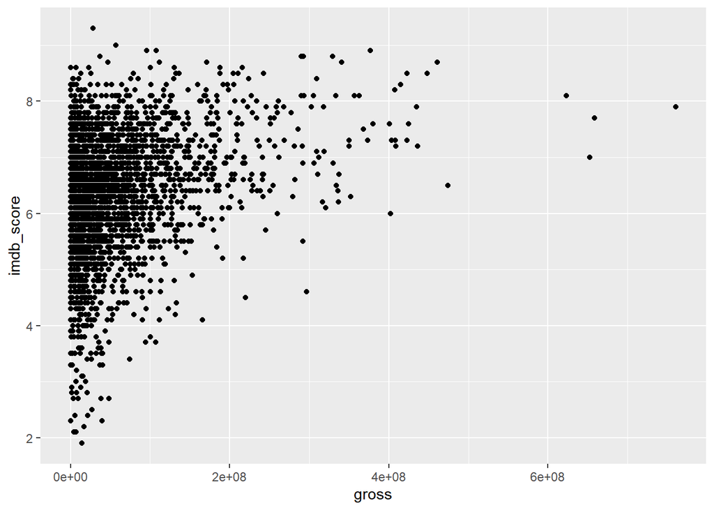

```r
ggplot(data=train, mapping=aes(x=gross, y=imdb_score)) +
  geom_point()
```

```r
with(train, cor(gross, imdb_score, use="complete.obs"))
```

```
## [1] 0.2630151
```

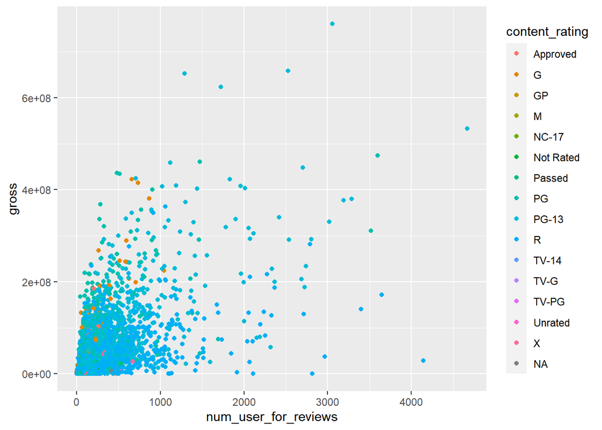

```r
ggplot(data=train, mapping=aes(x=num_user_for_reviews, y=gross, color = content_rating)) +
  geom_point()
```

```r
with(train, cor(gross, imdb_score, use="complete.obs"))
```

```
## [1] 0.2630151
```

### **Data Cleaning**

First, we want to clean out data. This will allow us to look through our variables, be able to visualize all of them and get an idea if which variables will be useful or not. Variables were split up between groups. My group was only given the **“plot_keywords”** since it was going to require a little more work then the others, which is found here first. All other data cleaning was done by toher classmates or the professor, which can be found later on.

##### **Plot Keywords**

```r
sum(is.na(train$plot_keywords)) #Number of missing plot keywords
```

```
## [1] 37
```

```r
train$plot_keywords[1] #Example output so we know what were working with.
```

```
## [1] "avatar|future|marine|native|paraplegic"
```

So, my group and I had many different ideas in how to handle this variable. But the first thing we needed to do was identify how we would handle the strings as shown above. It was decided that we would not only split the strings by the “|”, but also by spaces, and identify the most used (non-common) words and keep the top 100 words (since there were about 5000 words in total).

```r
#Finds top keywords in dataframe
keywordDF <- as.data.frame((train$plot_keywords %>% sapply(function(x) unlist(str_split(x, "[\\| ]"))) %>% unlist %>% unname %>% table %>% sort.int(decreasing = TRUE)))

#REmoves common words and takes top 100 words
keywordDF <- keywordDF[-which(keywordDF$. %in% stopwords::stopwords("en")), ] %>% head(100)

head(keywordDF)
```

```
##         . Freq
## 2  female  206
## 3  school  182
## 5   title  174
## 6  friend  169
## 7    love  165
## 10    new  154
```

Now that we know some of the most common words found in the key words, we needed to decide where to go from there. Some of the ideas we came across were: * Create dummy variables for each of the top 100 words, and give each variable some sort of score that would tell us which ones to keep. * Count how many of each of the top 100 words appears in each row and create a frequency variable. Also score these and create categorical variables on a scale of “Low”, “Medium”, and “High.” * Create a continuous variable between 0 and 1 that scores each movie on how significant their keywords are among the top 100.

I decided to try frequency and see how that turn out.

```r
#creates empty list
sumList = rep(0, length(keywordDF))

#retreaves list of every keyword by row
temp <- train$plot_keywords %>% sapply(function(x) unlist(str_split(x, "[\\| ]"))) %>% unname

#compares every row and counts number of top key words in that row
for (i in 1:length(temp)){
  sumList[i] <- sum(unique(temp[[i]]) %in% keywordDF$.)
}

#sets list into dataframe
train$num_Key_words <- sumList

#This will create categorical variables based on frequency, these limits are arbitrary
train$keyword_cat <- ifelse(train$num_Key_words < 2, "Low", "Medium")
train$keyword_cat <- ifelse(train$num_Key_words >= 4,"high", train$keyword_cat)
```

Here we will visualize our new variables.

[figure not shown]

```r
ggplot(data=train, mapping=aes(x=keyword_cat, y=imdb_score)) +
  geom_boxplot()  +
  xlab("Number of Key Words") + ylab("IMDB Score") +
  ggtitle("Key Word Category vs Score") + theme_light()
```

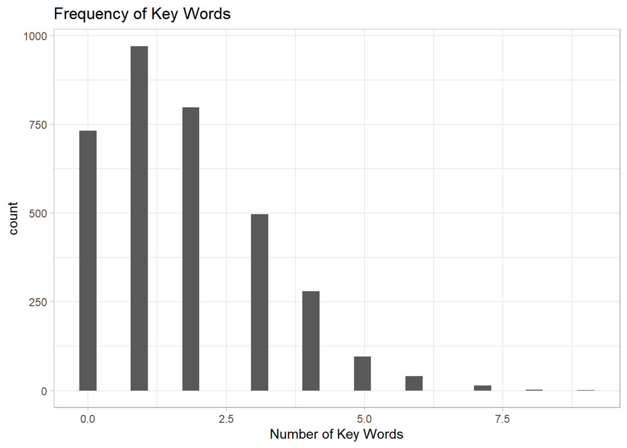

```r
ggplot(data=train, mapping=aes(x=num_Key_words)) +
  geom_histogram() +
  xlab("Number of Key Words") + ggtitle("Frequency of Key Words") + theme_light()
```

[figure not shown]

```r
ggplot(data=train, mapping=aes(x=num_Key_words, y=imdb_score)) +
  geom_point() +
  xlab("Number of Key Words") + ylab("IMDB Score") +
  ggtitle("Frequency of Key Words vs Score") + theme_light()
```

So as we can see there doesn’t really seem to be any significant pull in the frequency of keywords on our response variable, or, we don’t see that much correlation between the two.

Below I just wanted to test my hand in creating dummy variables, which I never ended up including, just wanted to do it for the flex (and learn cause I didn’t know how to do it).

```r
tempDF <- train$plot_keywords %>% sapply(function(x) unlist(str_split(x, "[\\| ]"))) %>% qdapTools::mtabulate()

tempDF <- tempDF[, colnames(tempDF) %in% keywordDF$. ]

#I dont want it taking up space in RAM though, so im deleting tempDF
rm(tempDF)
```

After we came aback as a group, we didn’t find anything too significant. As you can see above, the distributions don’t really tell us there would be any significant pull on our response variable. All our categories and distributions seem to be about the same, so we feel that this would not help us identify IMDB score.

#### **Rest of the Variables**

Here begins the rest of the data cleaning done by the rest of the members of the class and the professor.

###### **Basic Cleaning (Mean, meadian, mode imputations)**

```r
#Duration - only one missing so just look it up and fill it in
train[is.na(train$duration),]$duration <- 116

train[is.na(train$facenumber_in_poster),]$facenumber_in_poster <- mean(train$facenumber_in_poster, na.rm=TRUE)

## Color - mode imputation and convert to 0/1
train <- train %>%
  mutate(color=replace(color, is.na(color), "Color"))
train <- train %>%
  mutate(color = ifelse(color == "Color", 1, 0))

## Language - only five missing values so we replace them
missing_languages <- c("English", "None", "None", "None", "None")
train$language[is.na(train$language)] <- missing_languages


## num_user_for_reviews = mean imputation
train <- train %>%
  mutate(num_user_for_reviews=replace(num_user_for_reviews, is.na(num_user_for_reviews),
                                      mean(num_user_for_reviews, na.rm=TRUE)))

## num_critic_for_reviews - Median imputation
train[is.na(train[["num_critic_for_reviews"]]), "num_critic_for_reviews"] <- median(x = train[["num_critic_for_reviews"]], na.rm = TRUE)


## Director - convert to number of movies made by director
director_movie_count <- train %>%
  group_by(director_name) %>%
  summarise(movies_made = n())
train <- train %>%
  left_join(director_movie_count) %>%
  select(-director_name)
```

###### **Some of our Categorical Variables Needing Longer Code**

```r
## Content-rating - collapse GP --> PG and create "other"
## X --> NC-17, TV-?? --> TV, M-->PG13
train <- train %>%
  mutate(content_rating=fct_explicit_na(content_rating, na_level = "Unknown")) %>%
  mutate(content_rating=fct_collapse(content_rating, PG=c("GP", "PG"),
                                     NC17=c("X", "NC-17"),
                                     TV=c("TV-14", "TV-G", "TV-PG"),
                                     PG13=c("PG-13","M")))

## Genres - get the main genre and number of genres assigned
train <- train %>% mutate(main_genre=(str_split(genres, "\\|") %>%
                                      sapply(., FUN=function(x){x[1]})),
                        num_genre=(str_split(genres, "\\|") %>%
                                     sapply(., FUN=length)))
#Some genres only have 1 movie so create "other" category
#that contains all categories with less than 10 movies
other.cat <- train %>% group_by(main_genre) %>%
  summarize(n=n()) %>% filter(n<10) %>% pull(main_genre)
train <- train %>%
  mutate(main_genre=fct_collapse(main_genre, Other=other.cat))

train <- train %>%
  mutate(language=fct_collapse(language, Other=unique(language[language!="English"])))
```

###### **Linear Regression Imputation for Budget**

```r
## linear regression for budget
budget.lm <- lm(sqrt(budget)~num_critic_for_reviews+duration+num_voted_users+
                  cast_total_facebook_likes+title_year+
                  movie_facebook_likes+main_genre, data=train)
budget.preds <- (predict(budget.lm, newdata=(train %>% filter(is.na(budget)))))^2
train <- train %>%
  mutate(budget=replace(budget, is.na(budget), budget.preds))
```

```r
## stochastic regression for gross
gross.lm <- lm(sqrt(gross)~num_critic_for_reviews+duration+num_voted_users+
                  cast_total_facebook_likes+title_year+
                  movie_facebook_likes+main_genre+budget, data=train)

gross.preds <- (predict(gross.lm, newdata=(train %>% filter(is.na(gross))))+
                  rnorm(sum(is.na(train$gross)), 0, sigma(gross.lm)))^2

train <- train %>%
  mutate(gross=replace(gross, is.na(gross), gross.preds))
```

###### **actor_name Columns**

```r
## we created num_top_actors which tell us how many “top” actors were in a movie. “Top” actors were actors who were in multiple movies. All 3 actor column were used to decide who was a top actor.
all.actors <- train %>% select(actor_1_name, actor_2_name, actor_3_name) %>% do.call(c, args=.)
actors.freq <- data.frame(actor=all.actors) %>% filter(!is.na(actor)) %>%
  group_by(actor) %>% summarize(n=n()) %>%
  arrange(desc(n))
top.actors <- actors.freq %>% filter(n>10) %>% pull(actor)
train <- train %>%
  mutate(num_top_actors=(ifelse(actor_1_name%in%top.actors, 1, 0) +
                           ifelse(actor_2_name%in%top.actors, 1, 0) +
                           ifelse(actor_3_name%in%top.actors, 1, 0)))
```

###### **facebook_like Columns**

```r
## we made a column num_pop_actors for the total number of popular actors in a movie based off of their Facebook likes. With this, we decided to throw out cast_facebook likes as it seemed repetitive. It’s pretty mute since there’s also actor Facebook likes

actor.likes <- train %>% select(actor_1_facebook_likes, actor_2_facebook_likes, actor_3_facebook_likes) %>%
  do.call(c, args=.)
actors.likes <- data.frame(actor=all.actors, likes=actor.likes) %>%
  filter(!is.na(actor)) %>% group_by(actor) %>% summarize(likes=max(likes)) %>%
  arrange(desc(likes))
pop.actors <- actors.likes %>% filter(likes>quantile(likes, probs=0.99)) %>%
  pull(actor)
train <- train %>%
  mutate(num_pop_actors=(ifelse(actor_1_name%in%pop.actors, 1, 0) +
                           ifelse(actor_2_name%in%pop.actors, 1, 0) +
                           ifelse(actor_3_name%in%pop.actors, 1, 0)))
```

###### **Throwing out everything else (including the plot keywords)**

So after cleaning all of our data

```r
train <- train %>% select(-cast_total_facebook_likes, -movie_imdb_link, #-facenumber_in_poster,
                          -plot_keywords, -country,
                          -movie_facebook_likes, -director_facebook_likes, -actor_1_name, -actor_2_name, -actor_3_name, -actor_1_facebook_likes, -actor_2_facebook_likes, -actor_3_facebook_likes, -cast_total_facebook_likes, #
                          -keyword_cat, -genres)
```

Now that were moving in our modeling, I wanted to clear up some RAM, so here Im getting ride of cleaning variables and DF’s we created above.

```r
rm(list=c("gross.lm", "budget.lm", "actors.freq", "keywordDF", "temp", "director_movie_count", "actor.likes", "i", "gross.preds", "top.actors", "sumList", "pop.actors", "other.cat", "missing_languages", "budget.preds", "all.actors", "actors.likes"))
```

#### Writing cleaned data to csv, just cause

```r
write_csv(x=train, path="./CleanedIMDBData.csv")
```

I later decided to rename my data frame so its not to get confused with the notation when building our model

```r
imdb <- train
rm(train)
```

We took some time to go over some preprocessing techniques. Since we don’t care about inference, we only care about predictability, we are going to go through some different transformations to better fit our data to our model. Dummy variables, center and, scaling. the Caret Package can preprocess your data for you, so I simply have the code, but did not implement it into my dataframe.

```r
#Dummary Vars
IVTrands <- dummyVars(imdb_score~.-movie_title-Set, data=imdb)
imdb.iv <- predict(IVTrands, newdata = imdb) %>% as.data.frame() %>% bind_cols(., imdb %>% select(movie_title, Set, imdb_score))

#PreProcessing
pcTranss <- preProcess(x=imdb %>% select(-imdb_score), method = "pca")
imdb.pc <- predict(pcTranss, newdata = imdb)
```

```r
imdb.train <- imdb %>% filter(!is.na(imdb_score))
imdb.test <- imdb %>% filter(is.na(imdb_score))
```

### **Fitting a Model**

For this portion we spent some time going through how to use the caret package in R. We learned some basic functions and how to tune our parameters to better our RMSE in order to get the best score possible in this competition. With out professor, we went over these first two models, linear regression and elastic net.

##### **Linear Regression**

Simple linear regression, nothing special, just fitting our data.

```r
linreg <- train(form=imdb_score~.,
                data=(imdb.train %>% select(-Set, -movie_title)),
                method = "lm",
                trControl=trainControl(method="repeatedcv",
                                       number=10,
                                       repeats = 3)
                )

linreg$results
```

```
##   intercept     RMSE  Rsquared       MAE     RMSESD RsquaredSD      MAESD
## 1      TRUE 0.799378 0.4645926 0.5930272 0.04527485 0.03735646 0.02650484
```

##### **Elastic Net**

Using an elastic net method, we went through and learned out to tune the appropriate parameters.

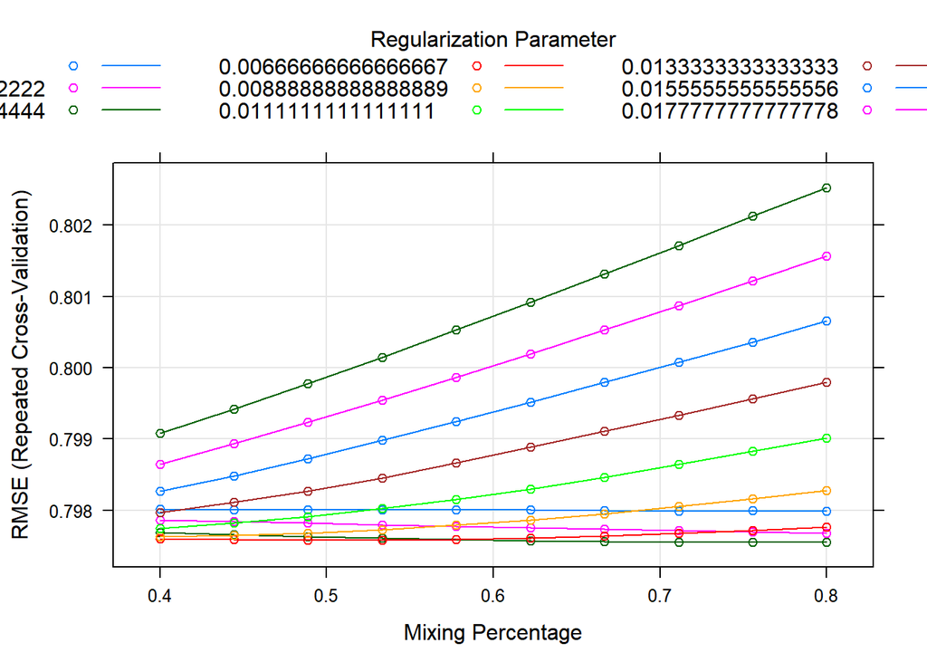

```r
elnet.grid <- expand.grid(alpha=seq(.4, .8, length=10),
                          lambda=seq(0, .02, length=10))
elnet <- train(form=imdb_score~.,
                data=(imdb.train %>% select(-Set, -movie_title)),
                method = "glmnet",
                trControl=trainControl(method="repeatedcv",
                                       number=10,
                                       repeats = 3),
               tuneGrid = elnet.grid
                )


plot(elnet)
```

```r
elnet$bestTune
```

```
##    alpha      lambda
## 93   0.8 0.004444444
```

```r
elnet$results
```

```
##         alpha      lambda      RMSE  Rsquared       MAE     RMSESD RsquaredSD
## 1   0.4000000 0.000000000 0.7980160 0.4668565 0.5920721 0.04538373 0.03711370
## 2   0.4000000 0.002222222 0.7978678 0.4670209 0.5919157 0.04543198 0.03707837
## 3   0.4000000 0.004444444 0.7976857 0.4672139 0.5916746 0.04554406 0.03704632
## 4   0.4000000 0.006666667 0.7976058 0.4673078 0.5915345 0.04566081 0.03702808
## 5   0.4000000 0.008888889 0.7976308 0.4672960 0.5915200 0.04577135 0.03701085
## 6   0.4000000 0.011111111 0.7977512 0.4671875 0.5915842 0.04586210 0.03697459
## 7   0.4000000 0.013333333 0.7979708 0.4669729 0.5917200 0.04595312 0.03694946
## 8   0.4000000 0.015555556 0.7982749 0.4666685 0.5919047 0.04604480 0.03694197
## 9   0.4000000 0.017777778 0.7986475 0.4662947 0.5921421 0.04613034 0.03694900
## 10  0.4000000 0.020000000 0.7990821 0.4658551 0.5924195 0.04622096 0.03698080
## 11  0.4444444 0.000000000 0.7980125 0.4668616 0.5920671 0.04538838 0.03711533
## 12  0.4444444 0.002222222 0.7978439 0.4670480 0.5918884 0.04544449 0.03707043
## 13  0.4444444 0.004444444 0.7976571 0.4672484 0.5916399 0.04557222 0.03703654
## 14  0.4444444 0.006666667 0.7975938 0.4673258 0.5915172 0.04570201 0.03701474
```

[output cut: 187 more lines]

```r
imdb.preds <- data.frame(Id=imdb.test$movie_title, Predicted = predict(elnet, newdata = imdb.test))

#write_csv(x=imdb.preds, path="./Peters_Submission_elnet.csv")
```

##### **Gradient Boosting**

For my own personal model, I decided to run with a stochastic gradient boost, mainly because it was the model that I wanted to learn more about. So I ran through the model and did some tuning in order to hammer down my tuning parameter. This result gave me the best out of the previous two models, so this is the one I am rolling with for the remainder of this analysis.

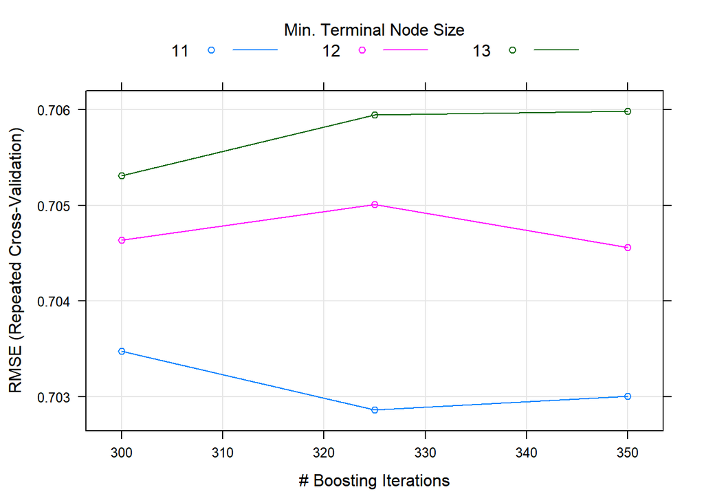

```r
tune.grid = expand.grid(n.trees = c(300, 325, 350),
                        interaction.depth = 10,
                        shrinkage = .05,
                        n.minobsinnode = c(11, 12, 13))

boost <- train(form=imdb_score~.,
                data=(imdb.train %>% select(-Set, -movie_title)),
                method = "gbm",
                trControl=trainControl(method="repeatedcv",
                                       number=10,
                                       repeats = 5),
               preProc = c("center","scale"),
               tuneGrid = tune.grid,
               verbose = FALSE
                )
beepr::beep()

plot(boost)
```

```r
boost$bestTune
```

```
##   n.trees interaction.depth shrinkage n.minobsinnode
## 2     325                10      0.05             11
```

```r
boost$results
```

```
##   shrinkage interaction.depth n.minobsinnode n.trees      RMSE  Rsquared
## 1      0.05                10             11     300 0.7034744 0.5851635
## 4      0.05                10             12     300 0.7046377 0.5838533
## 7      0.05                10             13     300 0.7053104 0.5831824
## 2      0.05                10             11     325 0.7028625 0.5859202
## 5      0.05                10             12     325 0.7050073 0.5834982
## 8      0.05                10             13     325 0.7059477 0.5824448
## 3      0.05                10             11     350 0.7030040 0.5858411
## 6      0.05                10             12     350 0.7045597 0.5840616
## 9      0.05                10             13     350 0.7059820 0.5825717
##         MAE     RMSESD RsquaredSD      MAESD
## 1 0.5071879 0.03626861 0.04084016 0.02393480
## 4 0.5079979 0.03472371 0.03814916 0.02335145
## 7 0.5079982 0.03499388 0.04057077 0.02384496
## 2 0.5067430 0.03651494 0.04078958 0.02409056
## 5 0.5080687 0.03528077 0.03869024 0.02375003
## 8 0.5081311 0.03507757 0.04056830 0.02393777
## 3 0.5067396 0.03621471 0.04073784 0.02377529
## 6 0.5078790 0.03524523 0.03893728 0.02389875
## 9 0.5081977 0.03489421 0.04062556 0.02415591
```

I uploaded a few predictions to Kaggle, and my lowest score was an RMSE of .66966 on the test set! The results above were from previous attempts to try and get a lower RMSE on my training set before the competition closed.

This simply saves the results to a csv so I can submit to kaggle

```r
imdb.preds <- data.frame(Id=imdb.test$movie_title, Predicted = predict(boost, newdata = imdb.test))

write_csv(x=imdb.preds, path="./Peters_Submission_Boost.csv")
```

And that’s it! his competition was a lot of fun and I had a blast learning new skills in data cleaning and model fitting. I would love any feedback you have to offer on this project, so let me know!